# Caso_Practico_1

## Contexto

El Informe Mundial de la Felicidad es una encuesta histórica sobre el estado de la felicidad global. El primer informe se publicó en 2012, el segundo en 2013, el tercero en 2015 y el cuarto en la actualización de 2016. El World Happiness 2017, que clasifica a 155 países según sus niveles de felicidad, se lanzó en las Naciones Unidas en un evento que celebra el día internacional de la felicidad el 20 de marzo. El informe continúa ganando reconocimiento mundial a medida que los gobiernos, las organizaciones y la sociedad civil utilizan cada vez más los indicadores de felicidad para informar de sus decisiones de formulación de políticas. Los principales expertos en todos los campos (economía, psicología, análisis de encuestas, estadísticas nacionales, salud, políticas públicas y más) describen cómo las mediciones de bienestar se pueden usar de manera efectiva para evaluar el progreso de las naciones.

## Contenido

Los puntajes y clasificaciones de felicidad utilizan datos de la encuesta mundial Gallup. Las puntuaciones se basan en las respuestas a la pregunta principal de evaluación de la vida formulada en la encuesta. Esta pregunta, conocida como la escalera de Cantril, les pide a los encuestados que piensen en una escalera con la mejor vida posible para ellos con un 10 y la peor vida posible con un 0 y que califiquen sus propias vidas actuales en esa escala. Las puntuaciones provienen de muestras representativas a nivel nacional para los años 2013-2016 y utilizan los pesos de Gallup para hacer que las estimaciones sean representativas. Las columnas que siguen la puntuación de felicidad estiman el grado en que cada uno de los seis factores (producción económica, apoyo social, esperanza de vida, libertad, ausencia de corrupción y generosidad) contribuyen a que las evaluaciones de vida sean más altas en cada país que en la distopía, un país hipotético que tiene valores iguales a los promedios nacionales más bajos del mundo para cada uno de los seis factores. No tienen impacto en el puntaje total reportado para cada país, pero sí explican por qué algunos países tienen una clasificación más alta que otros.

## ¿Qué es la distopía?

La distopía es un país imaginario que tiene las personas menos felices del mundo. El propósito de establecer la distopía es tener un punto de referencia con el que todos los países puedan ser comparados favorablemente (ningún país tiene un desempeño más pobre que la distopía) en términos de cada una de las seis variables clave, lo que permite que cada barra sea de ancho positivo. Las puntuaciones más bajas observadas para las seis variables clave, por lo tanto, caracterizan la distopía. La vida sería muy desagradable en un país con los ingresos más bajos del mundo, la esperanza de vida más baja, la generosidad más baja, la mayoría de la corrupción, la menor libertad y el menor apoyo social, en contraste con la utopía.

## Se pide:

Sobre los informes de felicidad de 2015 y 2016, realizar las siguientes exploraciones:

- Cargar los dos CSV como datasets.
- Identificar las columnas de ambos datasets: ¿hay diferencias entre ambos?
- Une ambos dataframes, sin importar que los dos compartan las mismas diferencias.
- Revisa el número de nulos que hay por cada columna, así como su porcentaje.
- Cambia los valores nulos de las columnas "Lower Confidence Interval" y "Upper Confidence Interval" por un número aleatorio entre el valor mínimo y máximo de la misma columna (un único número, no es necesario uno diferente para cada fila con valor nulo).
- Cambia los valores nulos de la columna "Standard Error" por su media al cuadrado.
- Obtén un resumen estadístico del dataframe sin valores nulos.
- Muestra de forma gráfica la relación entre la familia y la salud.
- Muestra de forma gráfica la relación entre la puntuación de felicidad y la confianza (corrupción del gobierno).
- Muestra la matriz de correlación del daframe.
- Tras unir los dataframes, los países aparecerán más de una vez. Muestra agrupado el dataframe por país con el valor máximo de felicidad, sin importar el año.
- ¿Tiene relación la felicidad con la generosidad? Muéstralo gráficamente a través de la puntuación de libertad.
- Muestra la distribución del grado de distopía en función de la región.

```python
#Importación de Librerías

import pandas as pd
import numpy as np
import matplotlib.pyplot as plt
import seaborn as sns
from plotnine import *
%matplotlib inline
```

```python
# Cargar CSV

df_1 = pd.read_csv('informe felicidad 2015.csv')
df_2 = pd.read_csv('informe felicidad 2016.csv')
```

```python
df_1.head()
```

|  | Country | Region | Happiness Rank | Happiness Score | Standard Error | Economy (GDP per Capita) | Family | Health (Life Expectancy) | Freedom | Trust (Government Corruption) | Generosity | Dystopia Residual |
| --- | --- | --- | --- | --- | --- | --- | --- | --- | --- | --- | --- | --- |
| 0 | Switzerland | Western Europe | 1 | 7.587 | 0.03411 | 1.39651 | 1.34951 | 0.94143 | 0.66557 | 0.41978 | 0.29678 | 2.51738 |
| 1 | Iceland | Western Europe | 2 | 7.561 | 0.04884 | 1.30232 | 1.40223 | 0.94784 | 0.62877 | 0.14145 | 0.43630 | 2.70201 |
| 2 | Denmark | Western Europe | 3 | 7.527 | 0.03328 | 1.32548 | 1.36058 | 0.87464 | 0.64938 | 0.48357 | 0.34139 | 2.49204 |
| 3 | Norway | Western Europe | 4 | 7.522 | 0.03880 | 1.45900 | 1.33095 | 0.88521 | 0.66973 | 0.36503 | 0.34699 | 2.46531 |
| 4 | Canada | North America | 5 | 7.427 | 0.03553 | 1.32629 | 1.32261 | 0.90563 | 0.63297 | 0.32957 | 0.45811 | 2.45176 |

```python
df_2.head()
```

|  | Country | Region | Happiness Rank | Happiness Score | Lower Confidence Interval | Upper Confidence Interval | Economy (GDP per Capita) | Family | Health (Life Expectancy) | Freedom | Trust (Government Corruption) | Generosity | Dystopia Residual |
| --- | --- | --- | --- | --- | --- | --- | --- | --- | --- | --- | --- | --- | --- |
| 0 | Denmark | Western Europe | 1 | 7.526 | 7.460 | 7.592 | 1.44178 | 1.16374 | 0.79504 | 0.57941 | 0.44453 | 0.36171 | 2.73939 |
| 1 | Switzerland | Western Europe | 2 | 7.509 | 7.428 | 7.590 | 1.52733 | 1.14524 | 0.86303 | 0.58557 | 0.41203 | 0.28083 | 2.69463 |
| 2 | Iceland | Western Europe | 3 | 7.501 | 7.333 | 7.669 | 1.42666 | 1.18326 | 0.86733 | 0.56624 | 0.14975 | 0.47678 | 2.83137 |
| 3 | Norway | Western Europe | 4 | 7.498 | 7.421 | 7.575 | 1.57744 | 1.12690 | 0.79579 | 0.59609 | 0.35776 | 0.37895 | 2.66465 |
| 4 | Finland | Western Europe | 5 | 7.413 | 7.351 | 7.475 | 1.40598 | 1.13464 | 0.81091 | 0.57104 | 0.41004 | 0.25492 | 2.82596 |

```python
# Columnas de ambos datasets

print(df_1.columns)
print(df_2.columns)
```

```
Index(['Country', 'Region', 'Happiness Rank', 'Happiness Score',
       'Standard Error', 'Economy (GDP per Capita)', 'Family',
       'Health (Life Expectancy)', 'Freedom', 'Trust (Government Corruption)',
       'Generosity', 'Dystopia Residual'],
      dtype='object')
Index(['Country', 'Region', 'Happiness Rank', 'Happiness Score',
       'Lower Confidence Interval', 'Upper Confidence Interval',
       'Economy (GDP per Capita)', 'Family', 'Health (Life Expectancy)',
       'Freedom', 'Trust (Government Corruption)', 'Generosity',
       'Dystopia Residual'],
      dtype='object')
```

Existen diferencias entre ambos datasets a nivel de columnas

En los datos del 2015 no se incluyen Lower Confidence Interval & Upper Confidence Interval

En los datos del 2016 no se incluye Standard Error

```python
#Unión de ambos datasets sin importar las diferencias

df = pd.concat([df_1, df_2],
               ignore_index=True, join='outer')

df.info()
```

```
<class 'pandas.core.frame.DataFrame'>
RangeIndex: 315 entries, 0 to 314
Data columns (total 14 columns):
 #   Column                         Non-Null Count  Dtype
---  ------                         --------------  -----
 0   Country                        315 non-null    object
 1   Region                         315 non-null    object
 2   Happiness Rank                 315 non-null    int64
 3   Happiness Score                315 non-null    float64
 4   Standard Error                 158 non-null    float64
 5   Economy (GDP per Capita)       315 non-null    float64
 6   Family                         315 non-null    float64
 7   Health (Life Expectancy)       315 non-null    float64
 8   Freedom                        315 non-null    float64
 9   Trust (Government Corruption)  315 non-null    float64
 10  Generosity                     315 non-null    float64
 11  Dystopia Residual              315 non-null    float64
 12  Lower Confidence Interval      157 non-null    float64
 13  Upper Confidence Interval      157 non-null    float64
dtypes: float64(11), int64(1), object(2)
memory usage: 34.6+ KB
```

```python
#Cantidad de Registros Nulos

print('Registros nulos por columna:\n',df.isnull().sum())
```

```
Registros nulos por columna:
 Country                            0
Region                             0
Happiness Rank                     0
Happiness Score                    0
Standard Error                   157
Economy (GDP per Capita)           0
Family                             0
Health (Life Expectancy)           0
Freedom                            0
Trust (Government Corruption)      0
Generosity                         0
Dystopia Residual                  0
Lower Confidence Interval        158
Upper Confidence Interval        158
dtype: int64
```

```python
#Porcentaje de Registros Nulos

print('% Registros nulos por columna:\n',df.isnull().sum()/len(df)*100)
```

```
% Registros nulos por columna:
 Country                           0.00000
Region                            0.00000
Happiness Rank                    0.00000
Happiness Score                   0.00000
Standard Error                   49.84127
Economy (GDP per Capita)          0.00000
Family                            0.00000
Health (Life Expectancy)          0.00000
Freedom                           0.00000
Trust (Government Corruption)     0.00000
Generosity                        0.00000
Dystopia Residual                 0.00000
Lower Confidence Interval        50.15873
Upper Confidence Interval        50.15873
dtype: float64
```

```python
# Imputación de Valores Nulos (Lower)

# Generación de Límites
a = df['Lower Confidence Interval'].min()
b = df['Lower Confidence Interval'].max()

c = np.random.uniform(a, b)

#Cambio de los Valores Nulos
df['Lower Confidence Interval'] = df['Lower Confidence Interval'].fillna(c)
```

```python
# Imputación de Valores Nulos (Upper)

# Generación de Límites
a = df['Upper Confidence Interval'].min()
b = df['Upper Confidence Interval'].max()

c = np.random.uniform(a, b)

#Cambio de los Valores Nulos
df['Upper Confidence Interval'] = df['Upper Confidence Interval'].fillna(c)
```

```python
# Imputación de Valores Nulos (Standard Error)

c = df['Standard Error'].mean()**2

#Cambio de los Valores Nulos
df['Standard Error'] = df['Standard Error'].fillna(c)
```

```python
df.info()
```

```
<class 'pandas.core.frame.DataFrame'>
RangeIndex: 315 entries, 0 to 314
Data columns (total 14 columns):
 #   Column                         Non-Null Count  Dtype
---  ------                         --------------  -----
 0   Country                        315 non-null    object
 1   Region                         315 non-null    object
 2   Happiness Rank                 315 non-null    int64
 3   Happiness Score                315 non-null    float64
 4   Standard Error                 315 non-null    float64
 5   Economy (GDP per Capita)       315 non-null    float64
 6   Family                         315 non-null    float64
 7   Health (Life Expectancy)       315 non-null    float64
 8   Freedom                        315 non-null    float64
 9   Trust (Government Corruption)  315 non-null    float64
 10  Generosity                     315 non-null    float64
 11  Dystopia Residual              315 non-null    float64
 12  Lower Confidence Interval      315 non-null    float64
 13  Upper Confidence Interval      315 non-null    float64
dtypes: float64(11), int64(1), object(2)
memory usage: 34.6+ KB
```

```python
# Resumen estadístico

df.describe()
```

|  | Happiness Rank | Happiness Score | Standard Error | Economy (GDP per Capita) | Family | Health (Life Expectancy) | Freedom | Trust (Government Corruption) | Generosity | Dystopia Residual | Lower Confidence Interval | Upper Confidence Interval |
| --- | --- | --- | --- | --- | --- | --- | --- | --- | --- | --- | --- | --- |
| count | 315.000000 | 315.000000 | 315.000000 | 315.000000 | 315.000000 | 315.000000 | 315.000000 | 315.000000 | 315.000000 | 315.000000 | 315.000000 | 315.000000 |
| mean | 79.238095 | 5.378949 | 0.025161 | 0.899837 | 0.892647 | 0.594054 | 0.399896 | 0.140532 | 0.239957 | 2.212032 | 4.234847 | 6.178970 |
| std | 45.538922 | 1.141531 | 0.025851 | 0.410780 | 0.286718 | 0.240790 | 0.150684 | 0.115490 | 0.130077 | 0.558728 | 1.322380 | 1.061113 |
| min | 1.000000 | 2.839000 | 0.002293 | 0.000000 | 0.000000 | 0.000000 | 0.000000 | 0.000000 | 0.000000 | 0.328580 | 2.732000 | 3.078000 |
| 25% | 40.000000 | 4.510000 | 0.002293 | 0.594900 | 0.739880 | 0.419645 | 0.295890 | 0.061315 | 0.151430 | 1.884135 | 3.193928 | 5.451000 |
| 50% | 79.000000 | 5.286000 | 0.018480 | 0.973060 | 0.937930 | 0.640450 | 0.413190 | 0.106130 | 0.218540 | 2.211260 | 3.193928 | 6.871555 |
| 75% | 118.500000 | 6.269000 | 0.043940 | 1.229000 | 1.087360 | 0.787640 | 0.516730 | 0.178610 | 0.311450 | 2.563470 | 5.231500 | 6.871555 |
| max | 158.000000 | 7.587000 | 0.136930 | 1.824270 | 1.402230 | 1.025250 | 0.669730 | 0.551910 | 0.819710 | 3.837720 | 7.460000 | 7.669000 |

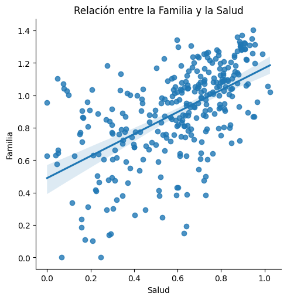

```python
#Relación entre Familia y Salud

sns.lmplot(data=df, x='Health (Life Expectancy)', y='Family')
plt.title('Relación entre la Familia y la Salud')
plt.xlabel('Salud')
plt.ylabel('Familia')
plt.show()
```

No es claro, pero si existe una diferencia entre familia y salud, entre más alto sea el valor de salud, mayor tiende a ser el valor de familia.

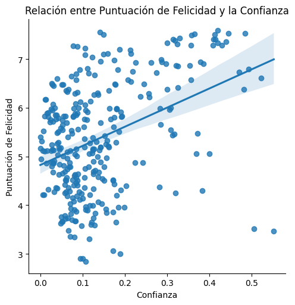

```python
#Relación entre Puntuación de Felicidad y Confianza

sns.lmplot(data=df, x='Trust (Government Corruption)', y='Happiness Score')
plt.title('Relación entre Puntuación de Felicidad y la Confianza')
plt.xlabel('Confianza')
plt.ylabel('Puntuación de Felicidad')
plt.show()
```

No existe una relación clara, la puntiación de felicidad puede ser alta tanto para puntuaciones bajas como altas de confianza.

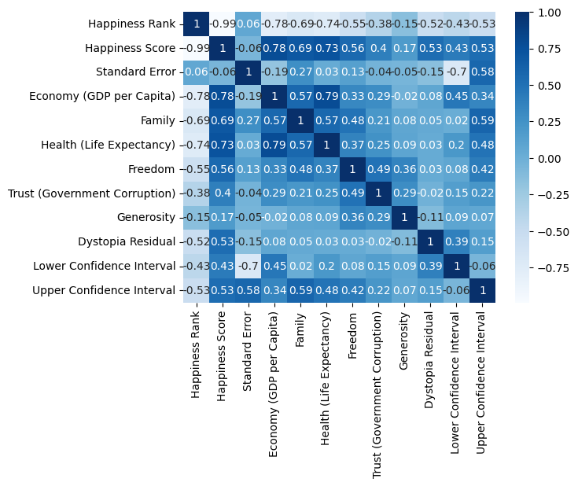

```python
#Matriz de correlación de las variables numéricas

sns.heatmap(round(df.iloc[:,2:].corr(),2), cmap='Blues', annot=True)
```

En la anterior visualización se destaca que en efecto la correlación entre Confianza y la Puntuación de Felicidad es relativamente baja.

```python
#Agrupación por país por valor máximo

df.groupby(['Country']).max()['Happiness Score']
```

```
Country
Afghanistan    3.575
Albania        4.959
Algeria        6.355
Angola         4.033
Argentina      6.650
               ...
Venezuela      6.810
Vietnam        5.360
Yemen          4.077
Zambia         5.129
Zimbabwe       4.610
Name: Happiness Score, Length: 164, dtype: float64
```

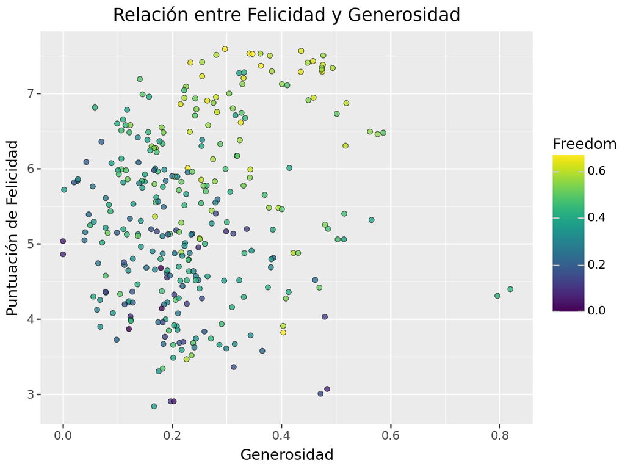

```python
#Relación entre Felicidad y Generosidad, a partir del valor de Libertad

(
    ggplot(df) +
    geom_point(aes(x='Generosity', y='Happiness Score',
                   fill = 'Freedom'),
                   alpha=0.8,
                   shape='o',
                   size = 2,
                   stroke = 0.2)
    + labs(title='Relación entre Felicidad y Generosidad',
           x = 'Generosidad',
           y = 'Puntuación de Felicidad')
)
```

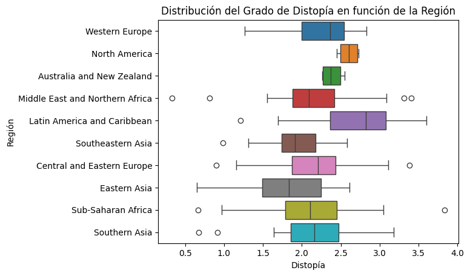

```python
#Distribución del Grado de Distopía en función de la Región

sns.boxplot(data=df, x= 'Dystopia Residual',
            y='Region',
            hue='Region',)
plt.title('Distribución del Grado de Distopía en función de la Región')
plt.xlabel('Distopía')
plt.ylabel('Región')
plt.show()
```